# Lab_1

1. Identify, and list here, what aesthetics are being used and which variables are being mapped to each aesthetic.

Aesthetic: x = income, y = life expectancy, group = income level:

2. Import the q1data.csv dataset.

```python
import pandas as pd
from plotnine import *
#hi
```

```python
df = pd.read_csv("Data\q1data.csv")

df1 = df.dropna()
df1.head()
```

|  | income | life_exp | population | year | country | four_regions | six_regions | eight_regions | world_bank_region |
| --- | --- | --- | --- | --- | --- | --- | --- | --- | --- |
| 0 | 1910.0 | 61.0 | 29200000.0 | 2010 | Afghanistan | asia | south_asia | asia_west | South Asia |
| 1 | 11100.0 | 78.1 | 2950000.0 | 2010 | Albania | europe | europe_central_asia | europe_east | Europe & Central Asia |
| 2 | 11100.0 | 74.7 | 36000000.0 | 2010 | Algeria | africa | middle_east_north_africa | africa_north | Middle East & North Africa |
| 3 | 46900.0 | 81.9 | 84500.0 | 2010 | Andorra | europe | europe_central_asia | europe_west | Europe & Central Asia |
| 4 | 7680.0 | 60.8 | 23400000.0 | 2010 | Angola | africa | sub_saharan_africa | africa_sub_saharan | Sub-Saharan Africa |

3. Recreate the plot as best you can using plotnine.

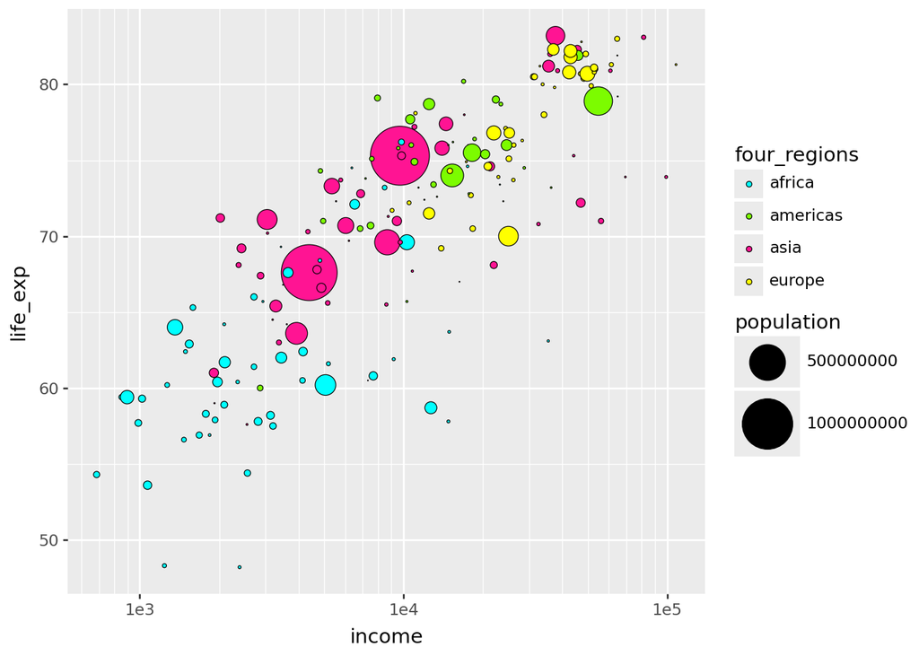

```python
# I looked up how to do the custom colors
world_regions = {
    "africa": "cyan",
    "americas": "lawngreen",
    "asia": "deeppink",
    "europe": "yellow"
}

# I looked up how to scale the y-axis using logarithms and change the bubble size
(ggplot(df1,
aes(
  x = "income",
  y = "life_exp",
  size = "population",
  fill = "four_regions"
))
+ geom_point(shape = "o", color = "black", stroke = 0.25)
+ scale_fill_manual(values = world_regions)
+ scale_x_log10()
+ scale_y_continuous()
+ scale_size_area(max_size=18)
)
```

4. What other geometries could you use here besides geom_point? Provide an actual plot of another geometry being used here and why it’s good or bad for visualizing these data.

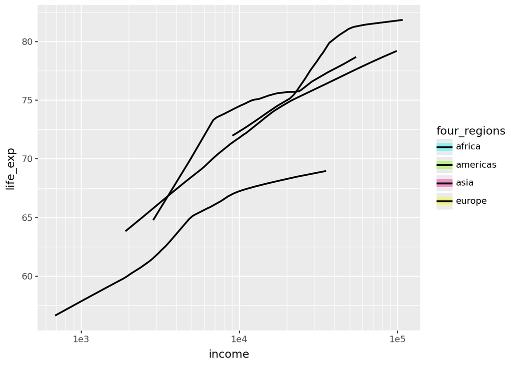

```python
# Same as above
world_regions = {
    "africa": "cyan",
    "americas": "lawngreen",
    "asia": "deeppink",
    "europe": "yellow"
}

# I looked up another plot type that would work wellt with these variables (smooth)
(ggplot(df1,
aes(
  x = "income",
  y = "life_exp",
  size = "population",
  fill = "four_regions"
))
+ geom_smooth()
+ scale_fill_manual(values = world_regions)
+ scale_x_log10()
+ scale_y_continuous()
+ scale_size_area(max_size=18)
)
```

I tried using a smooth plot instead of a point-based plot to represent the data. That being said, the key is quite unhelpful considering you cannot tell which wolrd region is which, but it does do a better job showing the general trend for the variables life expectancy and income. The area that it falls short is that it does not show the bubble size (indicating the population size) so that data is lost to us in this visualization.

1. Identify, and list here, what aesthetics are being used and which variables are being mapped to each aesthetic.

Aesthetic: x = exports (/ % of GDP), y = imports (/ % of GDP)

2. Import the q2data.csv dataset.

```python
df = pd.read_csv("Data\q2data.csv")

df1 = df.dropna()
df1.head()
```

|  | imports | exports | energy | year | country | four_regions | six_regions | eight_regions | world_bank_region |
| --- | --- | --- | --- | --- | --- | --- | --- | --- | --- |
| 1 | 36.7 | 11.5 | 427 | 1997 | Albania | europe | europe_central_asia | europe_east | Europe & Central Asia |
| 2 | 22.5 | 22.6 | 825 | 1997 | Algeria | africa | middle_east_north_africa | africa_north | Middle East & North Africa |
| 6 | 12.9 | 10.4 | 1660 | 1997 | Argentina | americas | america | america_south | Latin America & Caribbean |
| 7 | 52.8 | 19.0 | 610 | 1997 | Armenia | europe | europe_central_asia | europe_east | Europe & Central Asia |
| 9 | 20.5 | 19.6 | 5550 | 1997 | Australia | asia | east_asia_pacific | east_asia_pacific | East Asia & Pacific |

3. Recreate the plot as best you can using plotnine.

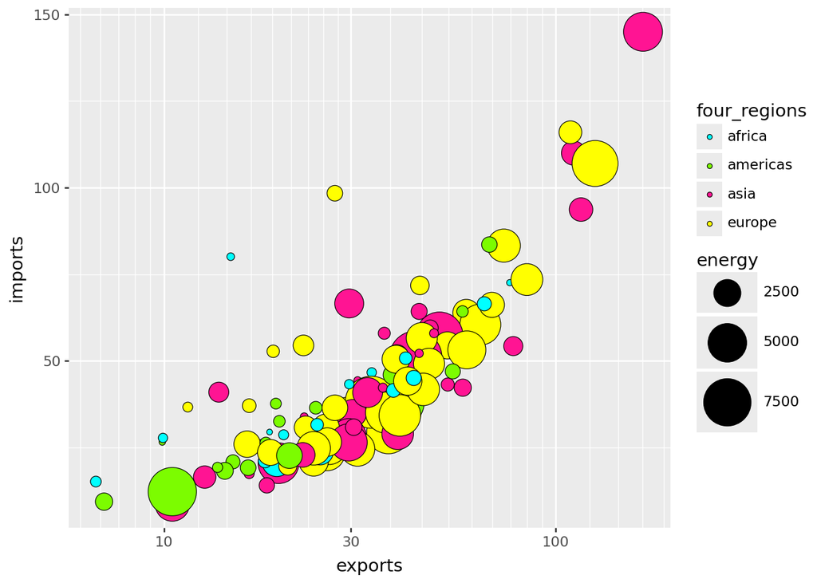

```python
# Same as above
world_regions = {
    "africa": "cyan",
    "americas": "lawngreen",
    "asia": "deeppink",
    "europe": "yellow"
}

# I looked up how to change the variable to a usable unmeric value
df1["energy"] = pd.to_numeric(df1["energy"], errors='coerce')

# Same as above (mostly)
(ggplot(df1,
aes(
  x = "exports",
  y = "imports",
  size = "energy",
  fill = "four_regions"
))
+ geom_point(shape = "o", color = "black", stroke = 0.25)
+ scale_fill_manual(values = world_regions)
+ scale_x_log10()
+ scale_y_continuous()
+ scale_size_area(max_size=18)
)
```

4. What other geometries could you use here besides geom_point? Provide an actual plot of another geometry being used here and why it’s good or bad for visualizing these data.

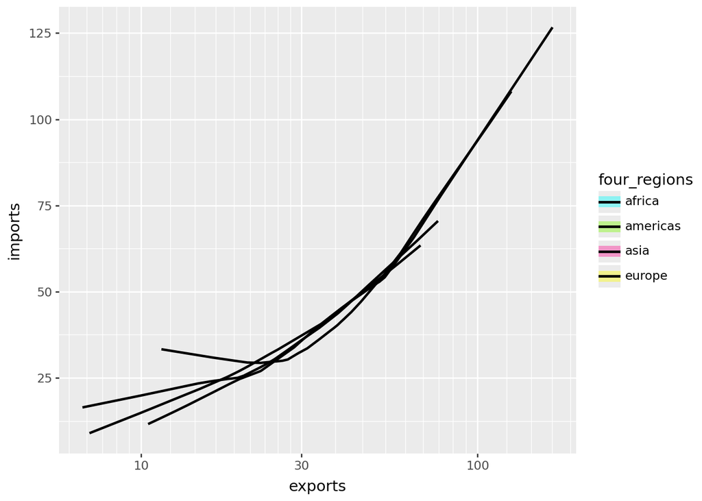

```python
# Same as above
world_regions = {
    "africa": "cyan",
    "americas": "lawngreen",
    "asia": "deeppink",
    "europe": "yellow"
}

# Same as above
df1["energy"] = pd.to_numeric(df1["energy"], errors='coerce')

# Same as above (mostly)
(ggplot(df1,
aes(
  x = "exports",
  y = "imports",
  size = "energy",
  fill = "four_regions"
))
+ geom_smooth()
+ scale_fill_manual(values = world_regions)
+ scale_x_log10()
+ scale_y_continuous()
+ scale_size_area(max_size=18)
)
```

1. Identify, and list here, what aesthetics are being used and which variables are being mapped to each aesthetic.

Aesthetic: x = Individuals using the internet, y = GDP / capita

2. Import the q3data.csv dataset.

```python
df = pd.read_csv("Data\q3data.csv")

df1 = df.dropna()
df1.head()
```

|  | internet_users | gdp | income | year | country | four_regions | six_regions | eight_regions | world_bank_region |
| --- | --- | --- | --- | --- | --- | --- | --- | --- | --- |
| 0 | 0.00456 | 330.0 | 1190.0 | 2001 | Afghanistan | asia | south_asia | asia_west | South Asia |
| 1 | 0.39000 | 2570.0 | 6780.0 | 2001 | Albania | europe | europe_central_asia | europe_east | Europe & Central Asia |
| 2 | 1.59000 | 3770.0 | 9230.0 | 2001 | Algeria | africa | middle_east_north_africa | africa_north | Middle East & North Africa |
| 4 | 11.30000 | 42600.0 | 35600.0 | 2001 | Andorra | europe | europe_central_asia | europe_west | Europe & Central Asia |
| 5 | 0.27000 | 2440.0 | 2900.0 | 2001 | Angola | africa | sub_saharan_africa | africa_sub_saharan | Sub-Saharan Africa |

3. Recreate the plot as best you can using plotnine.

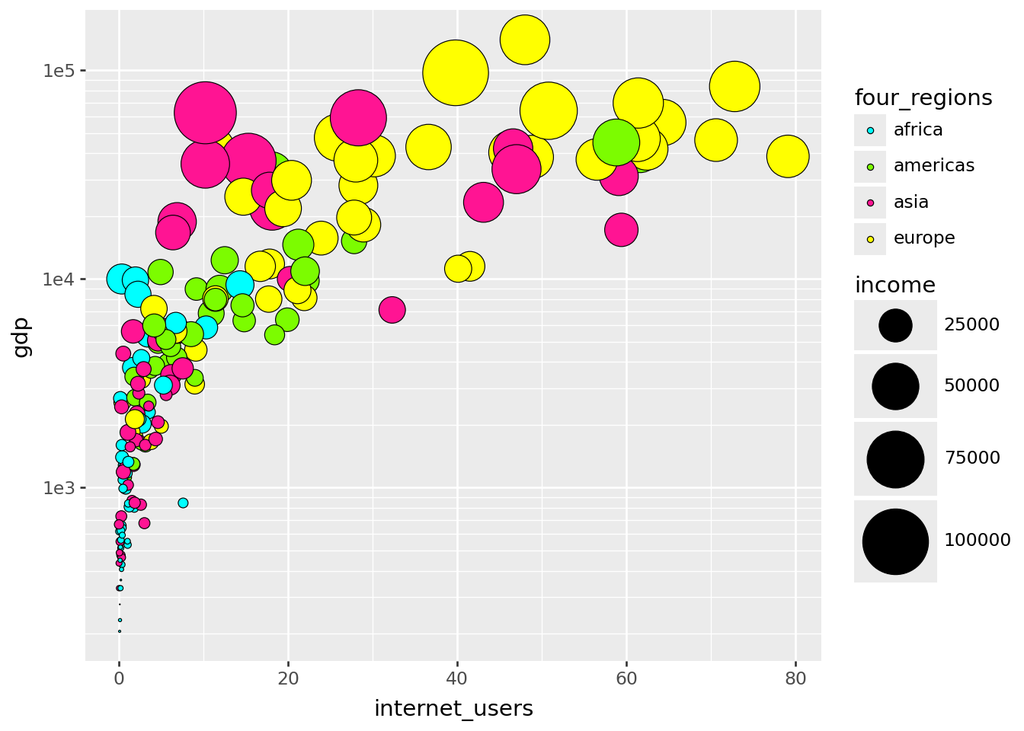

```python
# Same as above
world_regions = {
    "africa": "cyan",
    "americas": "lawngreen",
    "asia": "deeppink",
    "europe": "yellow"
}

# Same as above (mostly)
(ggplot(df1,
aes(
  x = "internet_users",
  y = "gdp",
  size = "income",
  fill = "four_regions"
))
+ geom_point(shape = "o", color = "black", stroke = 0.25)
+ scale_fill_manual(values = world_regions)
+ scale_y_log10()
+ scale_x_continuous()
+ scale_size_area(max_size=18)
)
```

4. What other geometries could you use here besides geom_point? Provide an actual plot of another geometry being used here and why it’s good or bad for visualizing these data.

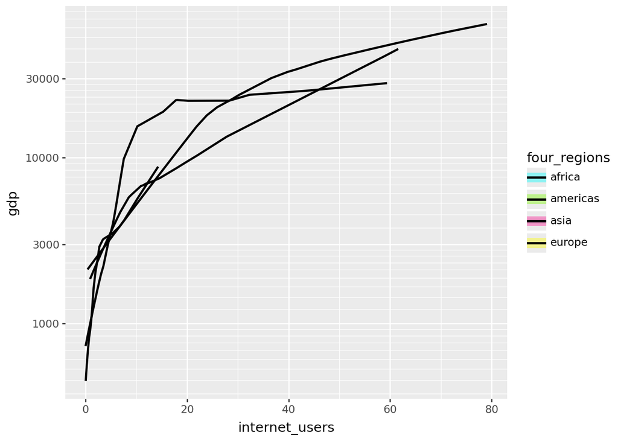

```python
# Same as above
world_regions = {
    "africa": "cyan",
    "americas": "lawngreen",
    "asia": "deeppink",
    "europe": "yellow"
}

# Same as above (mostly)
(ggplot(df1,
aes(
  x = "internet_users",
  y = "gdp",
  size = "income",
  fill = "four_regions"
))
+ geom_smooth()
+ scale_fill_manual(values = world_regions)
+ scale_y_log10()
+ scale_x_continuous()
+ scale_size_area(max_size=18)
)
```

I once again chose to represent the data using a smooth plot instead of a point-based plot to represent the data. The key continues to have issues, but the trend lines are quite helpful to see, where it can be hard to tell looking at many points of data. The data lost in this graph by the circle size represents income, which we do not have, but the trend lines are still quite helpful